# COMPSCIX 415.2 Homework 3

### 2. What parameters to geom_jitter() control the amount of jittering?

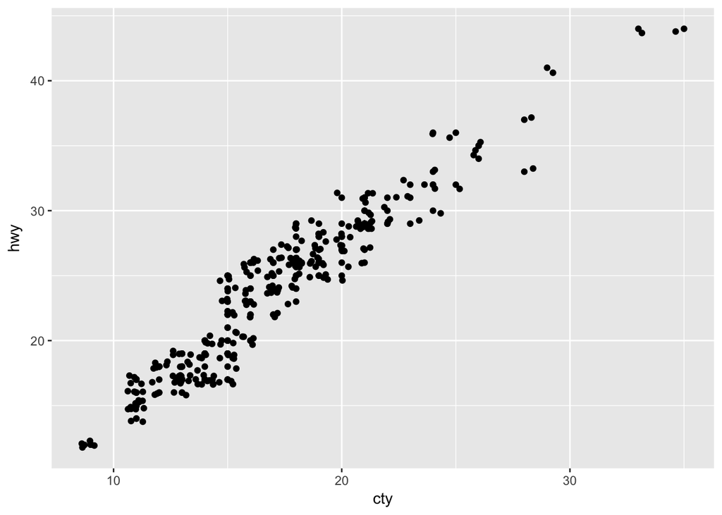

```r
ggplot(data = mpg, mapping = aes(x = cty, y = hwy)) +
    geom_point() +
    geom_jitter()
```

The jitter geom is a convenient shortcut for geom_point(position = “jitter”). It adds a small amount of random variation to the location of each point, and is a useful way of handling overplotting caused by discreteness in smaller datasets. Position: Position adjustment, either as a string, or the result of a call to a position adjustment function.

Width: Amount of vertical and horizontal jitter. The jitter is added in both positive and negative directions, so the total spread is twice the value specified here. If omitted, defaults to 40% of the resolution of the data: this means the jitter values will occupy 80% of the implied bins. Categorical data is aligned on the integers, so a width or height of 0.5 will spread the data so it’s not possible to see the distinction between the categories.

Height: Amount of vertical and horizontal jitter. The jitter is added in both positive and negative directions, so the total spread is twice the value specified here. If omitted, defaults to 40% of the resolution of the data: this means the jitter values will occupy 80% of the implied bins. Categorical data is aligned on the integers, so a width or height of 0.5 will spread the data so it’s not possible to see the distinction between the categories.

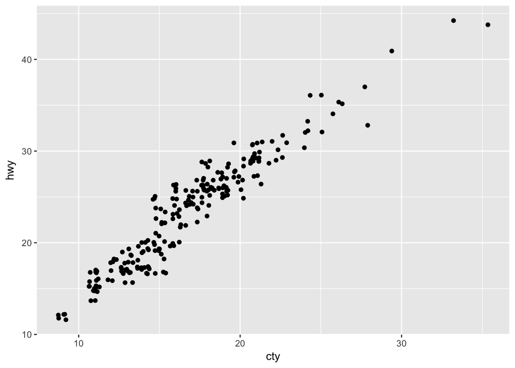

```r
ggplot(mpg, aes(cty, hwy)) + geom_jitter()
```

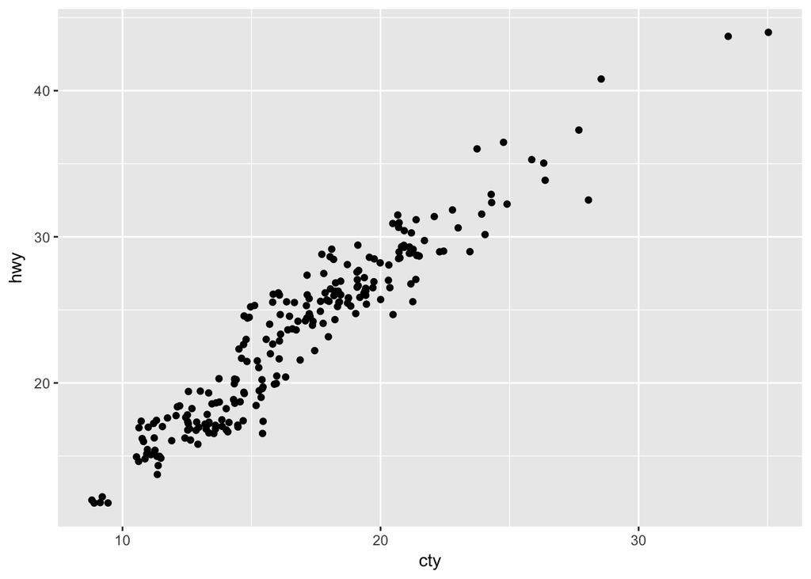

```r
ggplot(mpg, aes(cty, hwy)) + geom_jitter(width = 0.5, height = 0.5)
```

### 3. Compare and contrast geom_jitter() with geom_count().

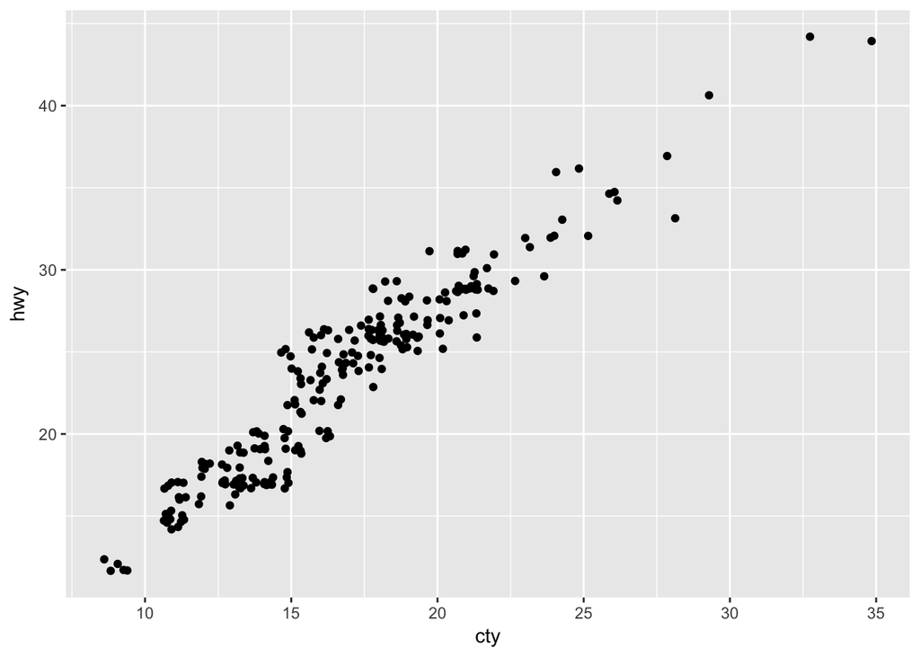

```r
ggplot(mpg, aes(cty, hwy)) + geom_jitter()
```

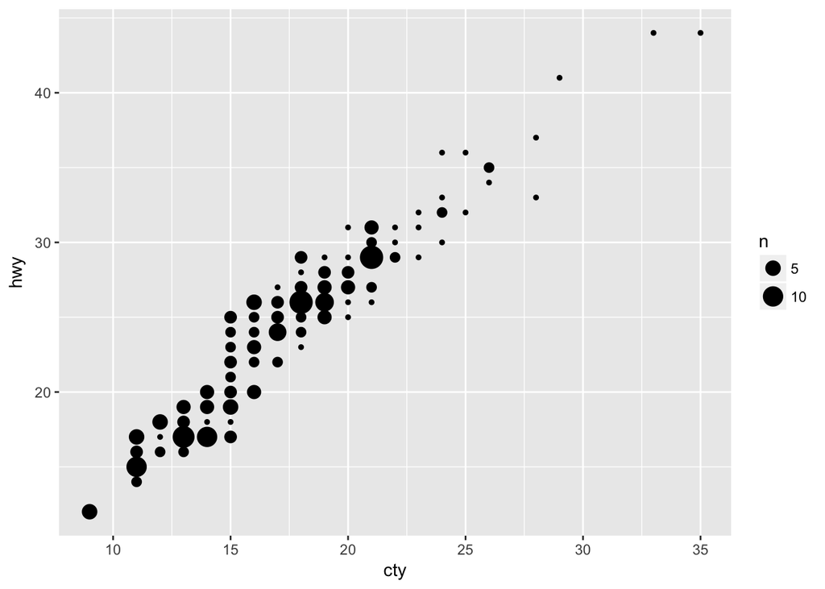

```r
ggplot(mpg, aes(cty, hwy)) + geom_count()
```

geom_count(): This is a variant geom_point that counts the number of observations at each location, then maps the count to point area. It useful when you have discrete data and overplotting.

geom_jitter(): It adds a small amount of random variation to the location of each point, and is a useful way of handling overplotting caused by discreteness in smaller datasets.

### 4. What’s the default position adjustment for geom_boxplot()? Create a visualisation of the mpg dataset that demonstrates it.

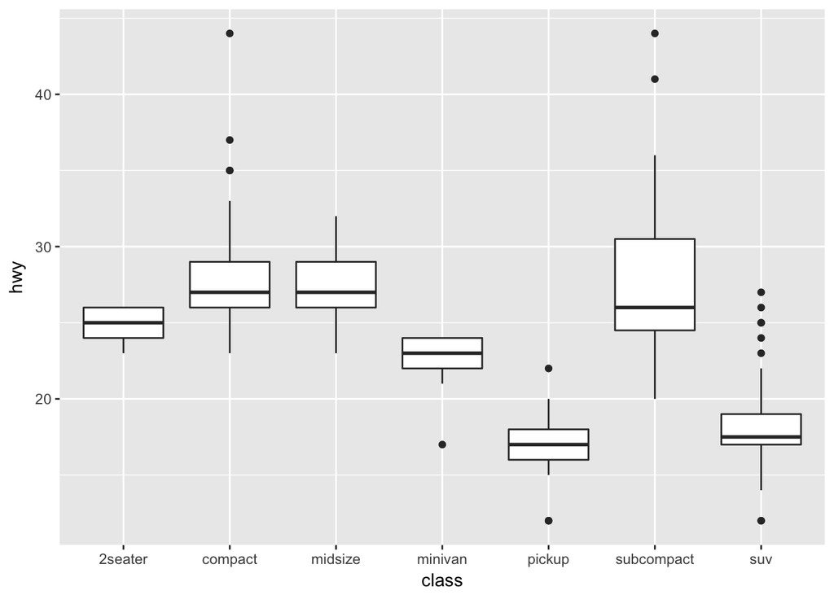

```r
ggplot(mpg, aes(class, hwy)) + geom_boxplot()
```

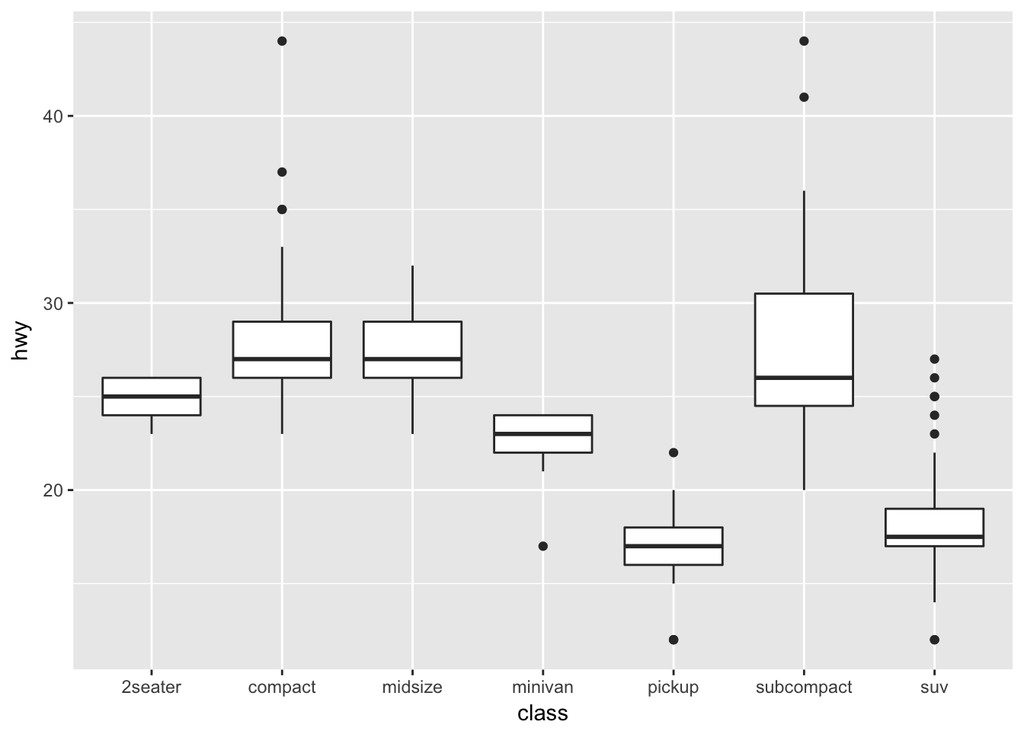

```r
ggplot(mpg, aes(class, hwy)) + geom_boxplot(position = "dodge")
```

The default is dodge, the points are moved to the side by a discrete amount

## Section 3.9.1: #2 and #4 only

### 2. What does labs() do? Read the documentation.

Good labels are critical for making your plots accessible to a wider audience. Ensure the axis and legend labels display the full variable name. Use the plot title and subtitle to explain the main findings. It’s common to use the caption to provide information about the data source.

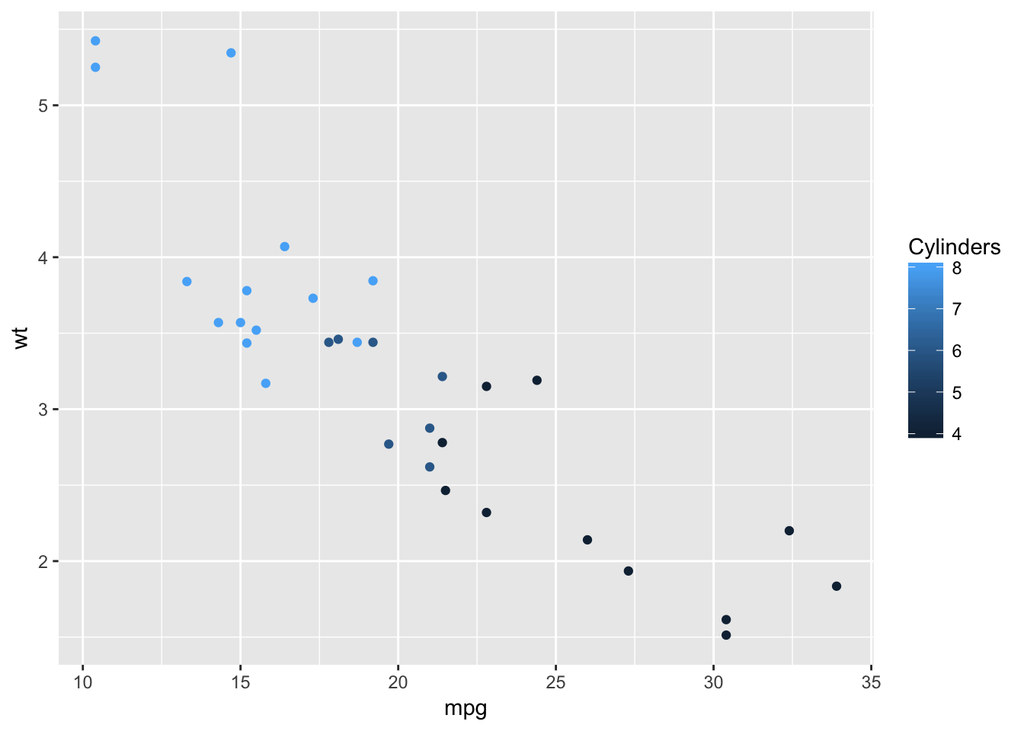

```r
p <- ggplot(mtcars, aes(mpg, wt, colour = cyl)) + geom_point()
p + labs(colour = "Cylinders")
```

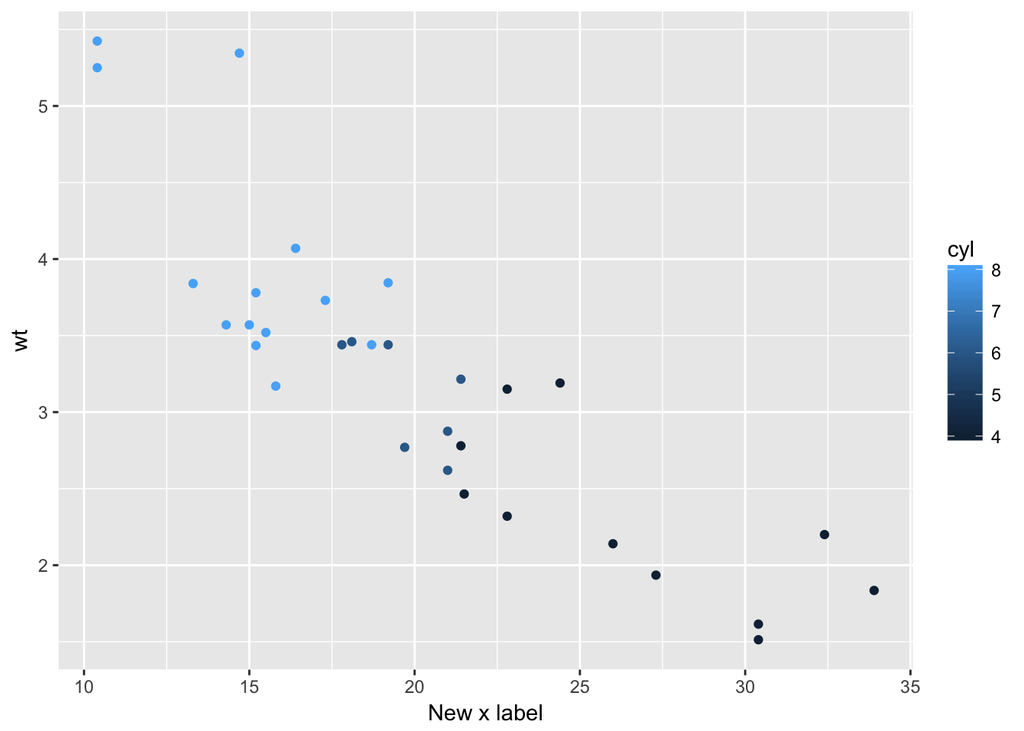

```r
p + labs(x = "New x label")
```